# R4ds ch. 3 Data visualization

play with the show.legend option. This will add the legend for the specified geom.

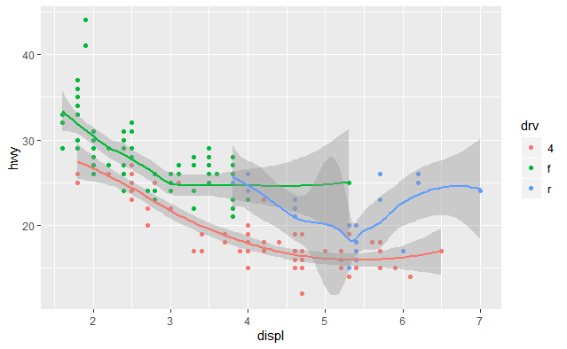

```r
ggplot(data = mpg, mapping = aes(x = displ, y = hwy, color = drv)) +
  geom_point(show.legend = T) +
  geom_smooth(se = T, show.legend = F)
```

3.6.6

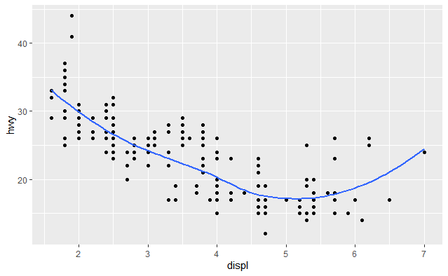

```r
ggplot( data = mpg, mapping = aes( x = displ, y = hwy)) + # plot scatterplot with smoothed line
  geom_point()+
  geom_smooth(se = F) # remove confidence interval
```

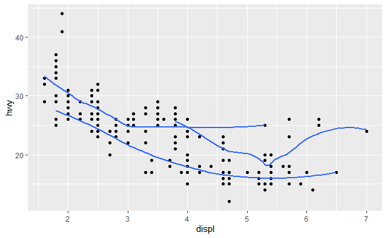

```r
ggplot( data = mpg,aes( x = displ, y = hwy) ) + # plot scatterplot and smooth lines
  geom_point() +
  geom_smooth(mapping = aes(group = drv)  , se = F) # add smooth line for each drv group
```

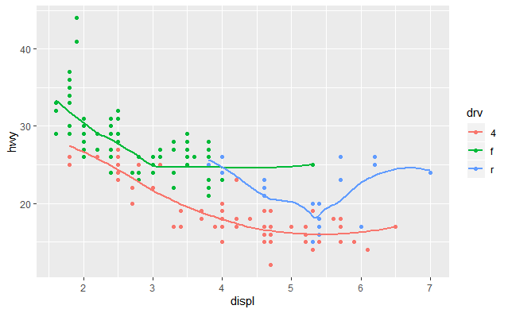

```r
ggplot(data = mpg, mapping = aes( x = displ, y = hwy, color = drv)) + # plot same but different color for each drv group
  geom_point() +
  geom_smooth(se = F) # no conf. intrvl.
```

plot different point colors for each drv group

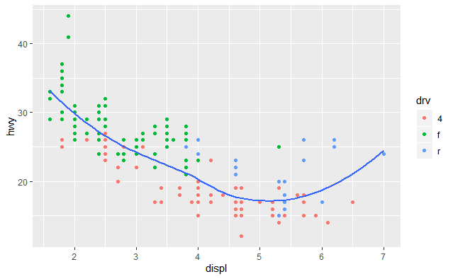

```r
ggplot( data = mpg, mapping = aes( x = displ, y = hwy) ) +
  geom_point(mapping = aes( color = drv)) +
  geom_smooth(se = F)
```

now plot different linetype for each drv group in smoothed line

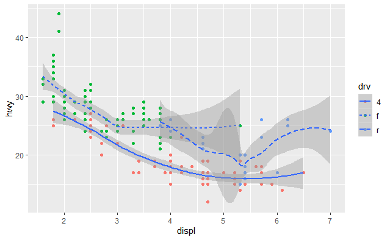

```r
ggplot( data = mpg , mapping = aes( x = displ, y = hwy)) +
  geom_point(mapping = aes(color = drv)) +
  geom_smooth(mapping = aes(linetype = drv))
```

3.7 statistical transformations

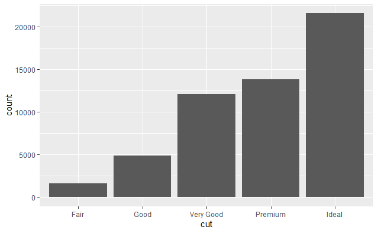

```r
ggplot( data = diamonds ) + # plot bar chart of diamond dataset
  geom_bar(mapping = aes( x = cut))
```

reproduce barchart with the stat_count variable and not a geom

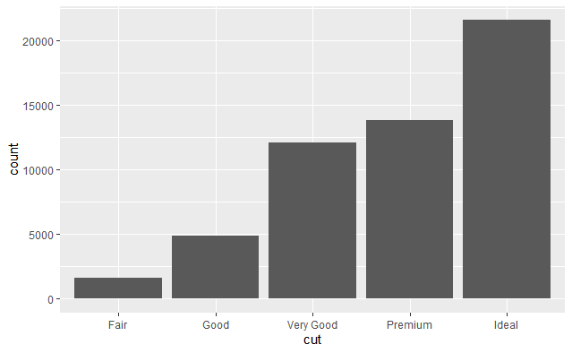

```r
ggplot(data = diamonds) +
  stat_count(mapping = aes(x = cut))
```

to override the default stat from count to something else use the following:

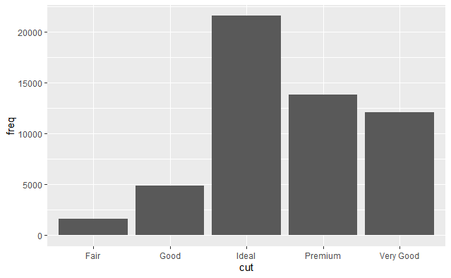

```r
demo = tribble( # create random numbers for diamond cut classes
  ~cut, ~freq, # x data, y data
  "Fair", 1610,
  "Good", 4906,
  "Very Good", 12082,
  "Premium", 13791,
  "Ideal", 21551
)
ggplot(data = demo) +
  geom_bar(mapping = aes( x = cut, y = freq), stat = "identity")
```

now override default mapping from transformed variable to aesthetics. Display bar chart of proportion rahter than count

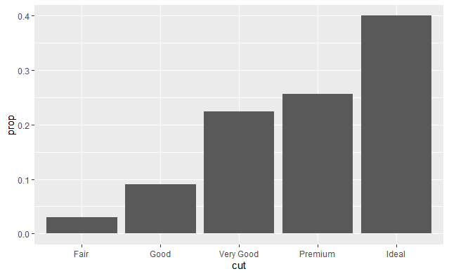

```r
ggplot(data = diamonds) +
  geom_bar(mapping = aes( x = cut, y = stat(prop), group = 1)) # y variable transforms data to a proportion of 1
```

for more computed variables see ?geom_bar -> computed variables